# edX Intro to Bioconductor section 3: Genomic annotation with Bioconductor

Josh Cook

2018-06-06

# Prologue: Detailed applications of GRanges

## Introduction to GenomicRanges

We will be using a library made for this course: `ERBS`.

```r
library(ERBS)
# estrogen binding site data from two cell lines
data("GM12878")
data("HepG2")
```

We can see `HepG2` is a `GRanges` object:

```r
HepG2
```

```
GRanges object with 303 ranges and 7 metadata columns:
        seqnames              ranges strand |      name     score       col signalValue
           <Rle>           <IRanges>  <Rle> | <numeric> <integer> <logical>   <numeric>
    [1]     chr2   20335378-20335787      * |      <NA>         0      <NA>      58.251
    [2]    chr20       328285-329145      * |      <NA>         0      <NA>      10.808
    [3]     chr6 168135432-168136587      * |      <NA>         0      <NA>      17.103
    [4]    chr19     1244419-1245304      * |      <NA>         0      <NA>      12.427
    [5]    chr11   64071828-64073069      * |      <NA>         0      <NA>       10.85
    ...      ...                 ...    ... .       ...       ...       ...         ...
  [299]     chr4     1797182-1797852      * |      <NA>         0      <NA>       9.681
  [300]     chr1 110198573-110199126      * |      <NA>         0      <NA>       7.929
  [301]    chr17   17734052-17734469      * |      <NA>         0      <NA>       5.864
  [302]     chr1   48306453-48306908      * |      <NA>         0      <NA>        5.66
  [303]    chr12 123867207-123867554      * |      <NA>         0      <NA>      13.211
           pValue       qValue      peak
        <numeric>    <numeric> <integer>
    [1]    75.899 6.143712e-72       195
    [2]    69.685 5.028065e-66       321
    [3]    54.311 7.930665e-51       930
    [4]    43.855 1.359756e-40       604
    [5]    40.977 7.333863e-38       492
    ...       ...          ...       ...
  [299]    10.057 1.423343e-08       402
  [300]    10.047 1.442076e-08       197
  [301]      9.99 1.638918e-08       227
  [302]     9.948 1.799414e-08       211
  [303]     9.918 1.921805e-08       163
  -------
  seqinfo: 93 sequences (1 circular) from hg19 genome
```

Get the data as a dataframe using the function `values`.

Access data by treating the object as a matrix. For example get the first 10 rows using `HepG2[1:10, ]`.

Get chromosomes using the function `seqnames(HepG2)`. This returns an `rle` that can be use like a normal `list` object. The `rle` class is a good storage device, especially if the sequence names were sorted.

Can order the object by chromosome and then location using the command `HepG2[order(HepG2),]`.

## Introduction to Genomic Ranges Assessment

1. In the video we used the `values` method to extract meta-data on the regions. An alternative, and preferred approach, is `mcols`. What is the median of the `signalValue` column for the HepG2 data?

```r
df <- mcols(HepG2)
median(df$signalValue)
```

```
[1] 7.024
```

2. In what chromosome is the region with the highest `signalValue` (copy and paste your answer)?

```r
HepG2[which(df$signalValue == max(df$signalValue)), ]
```

```
GRanges object with 1 range and 7 metadata columns:
      seqnames            ranges strand |      name     score       col signalValue    pValue
         <Rle>         <IRanges>  <Rle> | <numeric> <integer> <logical>   <numeric> <numeric>
  [1]     chrX 26801642-26802021      * |      <NA>         0      <NA>      91.779    15.102
            qValue      peak
         <numeric> <integer>
  [1] 3.129866e-13       198
  -------
  seqinfo: 93 sequences (1 circular) from hg19 genome
```

3. How many regions are from chromosome 16?

```r
sum(seqnames(HepG2) == 'chr16')
```

```
[1] 31
```

Make a histogram of the widths of the regions from all chromosomes (not just chr16). Note it has a heavy right tail. What is the median width?

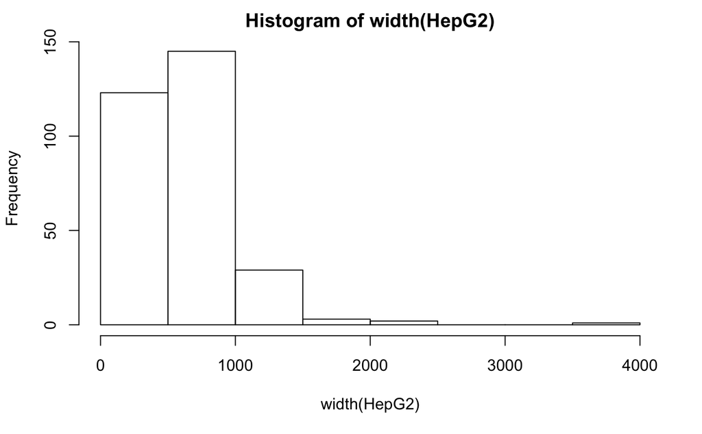

```r
hist(width(HepG2))
```

```r
median(width(HepG2))
```

```
[1] 560
```

## Genes as GRanges

We will be using the human genomic data:

```r
library(Homo.sapiens)
```

Can get all of the genes as GRanges:

```r
ghs <- genes(Homo.sapiens)
ghs
```

```
GRanges object with 23056 ranges and 1 metadata column:
        seqnames              ranges strand |       GENEID
           <Rle>           <IRanges>  <Rle> | <FactorList>
      1    chr19   58858172-58874214      - |            1
     10     chr8   18248755-18258723      + |           10
    100    chr20   43248163-43280376      - |          100
   1000    chr18   25530930-25757445      - |         1000
  10000     chr1 243651535-244006886      - |        10000
    ...      ...                 ...    ... .          ...
   9991     chr9 114979995-115095944      - |         9991
   9992    chr21   35736323-35743440      + |         9992
   9993    chr22   19023795-19109967      - |         9993
   9994     chr6   90539619-90584155      + |         9994
   9997    chr22   50961997-50964905      - |         9997
  -------
  seqinfo: 93 sequences (1 circular) from hg19 genome
```

A usefull function `precede`: “For each range in x, precede returns the index of the range in subject that is directly preceded by the range in x. Overlapping ranges are excluded. NA is returned when there are no qualifying ranges in subject.”

```r
res <- findOverlaps(HepG2, GM12878)
index <- queryHits(res)
erbs <- HepG2[index, ]
erbs <- GRanges(erbs)
index <- precede(erbs, ghs)
ghs[index[1:3]]
```

```
GRanges object with 3 ranges and 1 metadata column:
        seqnames            ranges strand |       GENEID
           <Rle>         <IRanges>  <Rle> | <FactorList>
   9741     chr2 20232411-20251789      - |         9741
  57761    chr20     361308-378203      + |        57761
  90007    chr19   1248552-1259142      + |        90007
  -------
  seqinfo: 93 sequences (1 circular) from hg19 genome
```

```r
erbs[1:3]
```

```
GRanges object with 3 ranges and 7 metadata columns:
      seqnames            ranges strand |      name     score       col signalValue    pValue
         <Rle>         <IRanges>  <Rle> | <numeric> <integer> <logical>   <numeric> <numeric>
  [1]     chr2 20335378-20335787      * |      <NA>         0      <NA>      58.251    75.899
  [2]    chr20     328285-329145      * |      <NA>         0      <NA>      10.808    69.685
  [3]    chr19   1244419-1245304      * |      <NA>         0      <NA>      12.427    43.855
            qValue      peak
         <numeric> <integer>
  [1] 6.143712e-72       195
  [2] 5.028065e-66       321
  [3] 1.359756e-40       604
  -------
  seqinfo: 93 sequences (1 circular) from hg19 genome
```

## Genes as GRanges Assessment

1. How many genes are represented in `ghs`?

```r
length(seqnames(ghs))
```

```
[1] 23056
```

2. What is the chromosome with the most genes?

```r
sort(table(seqnames(ghs)), decreasing=T)[1:5]
```

```
 chr1 chr19  chr2 chr11 chr17
 2326  1607  1464  1439  1337
```

3. Make a histogram of the widths of genes (use the width() on the GRanges object). This width gives the number of basepairs from the start of the gene to the end, so including exons and introns. Which best describes the width of genes?

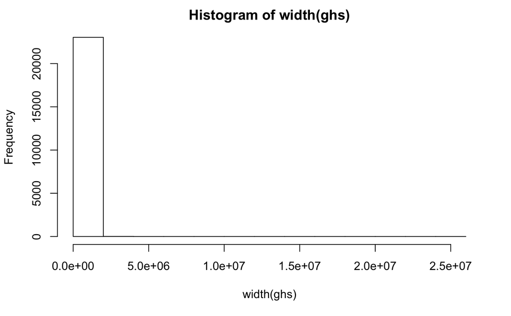

```r
hist(width(ghs))
```

4. What is the median gene width?

```r
median(width(ghs))
```

```
[1] 20115.5
```

## Finding the Nearest Gene

Find the gene nearest to each binding site:

```r
dis <- distance(erbs, ghs[index])
```

Can define distance differently by finding the nearest transcription start site. USe the `resize` ghs to one basepair at the beginning (ie. the TSS). The `distanceToNearest` to find the distance for each range in `x` to its nearest neighbor in `subject`.

```r
tss <- resize(ghs, 1)
distss <- distanceToNearest(x=erbs, subject=tss)
queryHits(distss)
```

```
 [1]  1  2  3  4  5  6  7  8  9 10 11 12 13 14 15 16 17 18 19 20 21 22 23 24 25 26 27 28 29 30
[31] 31 32 33 34 35 36 37 38 39 40 41 42 43 44 45 46 47 48 49 50 51 52 53 54 55 56 57 58 59 60
[61] 61 62 63 64 65 66 67 68 69 70 71 72 73 74 75
```

```r
dists <- values(distss)$distance
```

Use a histogram to see the distances:

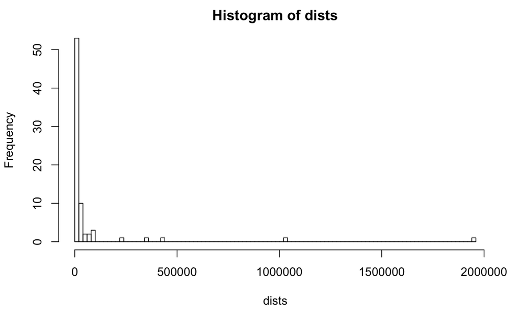

```r
hist(dists, nc=100)
```

Can get the genes that are close the binding sites:

```r
index <- subjectHits(distss)[dists < 1000]
```

To find out what keys are available in the `Homo.sapiens` db, can use the function `keytpes(Homo.sapiens)`. `GENEID` is one of the options, which is also in the `tss` object. Also use the `columns(Homo.sapiens)` command to see the available columns we can return.

Use the `select` function to query the Homo sapiens db:

```r
keys <- as.character(values(tss[index])$GENEID)
select(Homo.sapiens, keys=keys, keytype="GENEID", columns=c("SYMBOL", "GENENAME"))
```

```
      GENEID                                             GENENAME   SYMBOL
1      80023                                          neurensin 2    NRSN2
2       2101                      estrogen related receptor alpha    ESRRA
3       7086                                        transketolase      TKT
4       5478                           peptidylprolyl isomerase A     PPIA
5     286262                                              taperin     TPRN
6      79696                  zinc finger C2HC-type containing 1C  ZC2HC1C
7      79763                  isochorismatase domain containing 2    ISOC2
8      60493                                FAST kinase domains 5  FASTKD5
9     130074         family with sequence similarity 168 member B  FAM168B
10      4967                           oxoglutarate dehydrogenase     OGDH
11      8508                                    nipsnap homolog 1 NIPSNAP1
12      9377                      cytochrome c oxidase subunit 5A    COX5A
13    374291       NADH:ubiquinone oxidoreductase core subunit S7   NDUFS7
14     84331     MAPK regulated corepressor interacting protein 2   MCRIP2
```

[output cut: 27 more lines]

## Finding and getting annotation for closest gene Assessment

In this assessment (which deals with topics in several videos) we will find the closest genes to some of our binding sites. We will use a consensus set of regions. In the video we did it like this:

```r
library(Homo.sapiens)
ghs = genes(Homo.sapiens)
res = findOverlaps(HepG2,GM12878)
erbs = HepG2[queryHits(res)]
erbs = granges(erbs)
erbs2= intersect(HepG2,GM12878)
```

2. Using what you learned in the video, convert the `ghs` object to one that represents just the `tss`.

What is the TSS (Transcription Start Site) of the gene with ID: 100113402?

```r
tss <- resize(ghs, 1)
tss["100113402",]
```

```
GRanges object with 1 range and 1 metadata column:
            seqnames    ranges strand |       GENEID
               <Rle> <IRanges>  <Rle> | <FactorList>
  100113402    chr16  70563402      + |    100113402
  -------
  seqinfo: 93 sequences (1 circular) from hg19 genome
```

3. Now using the erbs regions defined in a previous question:

```r
res = findOverlaps(HepG2,GM12878)
erbs = HepG2[queryHits(res)]
erbs = granges(erbs)
```

What is the GENEID of the gene with TSS closest to the 4th region of `erbs`?

```r
n <- nearest(erbs, tss)
tss[n]
```

```
GRanges object with 75 ranges and 1 metadata column:
         seqnames    ranges strand |       GENEID
            <Rle> <IRanges>  <Rle> | <FactorList>
    9741     chr2  20251789      - |         9741
   80023    chr20    327370      + |        80023
     513    chr19   1241749      + |          513
    2101    chr11  64073044      + |         2101
   81553     chr2  16847134      - |        81553
     ...      ...       ...    ... .          ...
    5037    chr12 118573870      + |         5037
  113444     chr1  35325417      - |       113444
   56181     chr1  26146397      + |        56181
  347734     chr6  44225283      - |       347734
    2948     chr1 110198698      + |         2948
  -------
  seqinfo: 93 sequences (1 circular) from hg19 genome
```

4. In the question above, you identified a gene. Use the `select` function to determine which is the `SYMBOL` of this gene.

```r
select(Homo.sapiens, keys="2101", keytype="GENEID", columns=c("SYMBOL"))
```

```
  GENEID SYMBOL
1   2101  ESRRA
```

## Getting the Sequence of Regions

In this video, we’re going to show how to use the full reference genomic sequence of Homo sapiens in order to look at the content of the binding sites for the estrogen receptor.

```r
library(BSgenome.Hsapiens.UCSC.hg19)
Hsapiens
```

```
Human genome:
# organism: Homo sapiens (Human)
# provider: UCSC
# provider version: hg19
# release date: Feb. 2009
# release name: Genome Reference Consortium GRCh37
# 93 sequences:
#   chr1                  chr2                  chr3                  chr4
#   chr5                  chr6                  chr7                  chr8
#   chr9                  chr10                 chr11                 chr12
#   chr13                 chr14                 chr15                 chr16
#   chr17                 chr18                 chr19                 chr20
#   ...                   ...                   ...                   ...
#   chrUn_gl000233        chrUn_gl000234        chrUn_gl000235        chrUn_gl000236
#   chrUn_gl000237        chrUn_gl000238        chrUn_gl000239        chrUn_gl000240
#   chrUn_gl000241        chrUn_gl000242        chrUn_gl000243        chrUn_gl000244
#   chrUn_gl000245        chrUn_gl000246        chrUn_gl000247        chrUn_gl000248
#   chrUn_gl000249
# (use 'seqnames()' to see all the sequence names, use the '$' or '[[' operator to access a
# given sequence)
```

Can use the `getSeq` function to extract a set of sequences (or subsequences) from a sequence container like a `BSgenome` object.

```r
hepseq <- getSeq(Hsapiens, HepG2)
```

This returns a collection of DNA strings for each binding site in `HepG2`.

Let’s make a control set of strings:

```r
rhepseq <- getSeq(Hsapiens, shift(HepG2, 2500))
```

Now we will count the number of appearances of the motif `mot` using `vcountPattern`.

```r
mot <- "TCAAGGTC"
sum(vcountPattern(mot, hepseq))
```

```
[1] 24
```

```r
sum(vcountPattern(mot, reverseComplement(hepseq)))
```

```
[1] 45
```

```r
sum(vcountPattern(mot, rhepseq))
```

```
[1] 4
```

```r
sum(vcountPattern(mot, reverseComplement(rhepseq)))
```

```
[1] 4
```

In a real analysis, we would need to account for deviations from the motif using a matrix representation through the package `MotifDb` and a pattern matching programs such as `MEME` or `FIMO` (I’m not sure these are available in R).

## Getting Sequence Assessment

```r
library(ERBS)
library(GenomicRanges)
data(HepG2)
data(GM12878)
res = findOverlaps(HepG2,GM12878)
erbs = HepG2[queryHits(res)]
erbs = granges(erbs)
library(BSgenome.Hsapiens.UCSC.hg19)
```

2. Now use the `getSeq` function to extract the sequence of each region in `erbs`. Then compute the GC-content (the number of C’s + the number of G’s divided by the length of sequence) of each. What is the median GC-content?

```r
seqs <- getSeq(Hsapiens,erbs)
gc <- alphabetFrequency(seqs)[,2:3]
n <- width(erbs)
gccontent <- rowSums(gc)/n
median(gccontent)
```

```
[1] 0.652568
```

3. Now create a control set of regions by shifting erbs by 10000. What is the median GC-content of these control regions?

```r
seqs <- getSeq(Hsapiens, shift(erbs, 10000))
gc <- alphabetFrequency(seqs)[, 2:3]
n <- width(erbs)
gccontent <- rowSums(gc)/n
median(gccontent)
```

```
[1] 0.4860174
```

# Annotation of genes and transcripts

## Reference sequence packages for model organisms